# Package ‘odr’

Zuchao Shen & Benjamin Kelcey

2025-10-31

The costs of sampling each additional unit in (multilevel) experimental studies vary across treatment conditions (and levels of hierarchy). This package is a tool to identify the optimal sample allocation in experimental studies such that statistical power is maximized under a fixed budget. The designs covers experiments detecting main, mediation, and moderation effects (and some of the combinations).

# 1. Optimal Design Parameters

Optimal design parameters in an optimal sample allocation include

- the optimal sample sizes at each of the levels except the top level because the top-level sample size will be determined by total budget or power once all other parameters are decided, and
- the proportion of units assigned to the treatment condition at the level of randomization.

Researchers can fix one or more of the optimal design parameters for constrained optimal sample allocation and solve for the remainder of optimal design parameters.

# 2. Designs Detecting Main Effects

## Designs and Functions

Functions for Designs Detecting Main Effects

[output not shown]

## Functions

### *od* function

This function calculates optimal sample allocation parameters with and without constraint(s). For each type of multilevel experimental studies, there is an additional number (and one additional letter m) to be added to the general function name. For example, the function for two-level cluster randomized trials is *od.2*, the function for two-level multisite randomized trials is *od.2m*.

### *power* function

This function performs power analyses with and without accommodating cost structures of sampling. For power analysis accommodating cost structures, depending on which one parameter is left, the function calculates required budget (and sample size), statistical power, and minimum detectable effect size. For conventional power analysis without accommodating cost structures of sampling, this function calculates required sample size, statistical power, and minimum detectable effect size. For each type of experiments, there is an additional number (and an additional letter m) to be added to the general function name. For example, the function for two-level cluster randomized trials is *power.2*, the function for two-level multisite randomized trials is *power.2m*.

### *re* function

This function calculates relative efficiency values between two designs. An alternative name for this function is *rpe* that stands for “relative precision and efficiency”.

# 3. Designs Detecting Mediation Effects

## Designs and Functions

Functions for Designs Detecting Mediation Effects (In Preparation)

| Design | OD Function | Power Function |
| --- | --- | --- |
| Simple Experiments | od.1.111 | power.1.111 |
| 2-Level CRTs | od.2.221 | power.2.221 |
| 2-Level MRTs | od.2m.111 | power.2m.111 |

## Rules for Function Names

There are two categories of functions for designs detecting mediation effects. They are *od* and *power* functions. The function names follow additional rules as these functions will add additional numbers to represent the levels of the treatment assignment, the mediator and the outcome. For example, *od.2.221* is the *od* function for two-level cluster-randomized trials (.2) with the treatment assignment and the mediator at the level two, and the outcome at the level 1 (.221). *od.2m.111* is the *od* function for two-level multisite-randomized trials (.2m) with the treatment assignment, the mediator, and the outcome at the level one (.111).

## Functions

There are two categorical functions for designs detecting mediation effects and they are *od* and *power*. *od* function can calculate optimal design parameters with and without a constraint(s). *power* function can perform power analysis.

# 4. Designs Detecting Moderation (and Main) Effects

## Designs and Functions

Functions for Designs Detecting Moderation Effects (In Preparation)

| Design | OD Function | Power Function |
| --- | --- | --- |
| Simple Experiments | od.1.111m | power.1.111m |
| 2-Level CRTs | od.2.221m | power.2.221m |
| 2-Level MRTs | od.2m.111m | power.2m.111m |

## Rules for Function Names

There are two categories of functions for designs detecting moderation effects. They are *od* and *power* functions. The function names follow additional rules as these functions will add additional numbers to represent the levels of the treatment assignment, the moderator and the outcome. For example, *od.2.221m* is the *od* function for two-level cluster-randomized trials (.2) with the treatment assignment and the moderator at the level two, and the outcome at the level 1 (.221), and for moderators (m) rather than for mediators. *od.2m.111m* is the *od* function for two-level multisite-randomized trials (.2m) with the treatment assignment, the moderator, and the outcome at the level one (.111) for moderators (m).

## Functions

There are two categorical functions for designs detecting mediation effects and they are *od* and *power*. *od* function can calculate optimal design parameters with and without a constraint(s). *power* function can perform power analysis.

# 5. Examples for Main Effects

## Function *od*

Given cost structure (i.e., the costs of sampling each unit at different levels and treatment conditions), this function solves the optimal sample allocation with and without constraints.

To solve the optimal sample allocation of a two-level cluster-randomized trial, we need the following information

- icc: intraclass correlation coefficient
- r12: the proportion of level-one outcome variance explained by covariates
- r22: the proportion of level-two outcome variance explained by covariates
- c1: the cost of sampling each additional level-one unit in the control condition
- c2: the cost of sampling each additional level-two unit in the control condition
- c1t: the cost of sampling each additional level-one unit in the experimental condition
- c2t: the cost of sampling each additional level-two unit in the experimental condition
- m: a total fixed budget used to plot the variance curves, default value is the cost of sampling 60 level-two units across treatment conditions.

```r
library(odr)
```

```r
 # unconstrained optimal design
myod1 <- od.2(icc = 0.2, r12 = 0.5, r22 = 0.5, c1 = 1, c2 = 5, c1t = 1, c2t = 50,
              varlim = c(0.01, 0.02))
```

```
## The optimal level-1 sample size per level-2 unit (n) is 8.878572.
## The optimal proportion of level-2 units in treatment (p) is 0.326828.
```

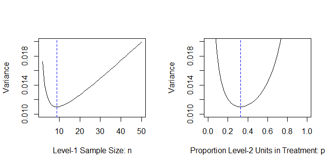

```r
 # The function by default prints messages of output and plots the variance curves; one can turn off message and specify one or no plot.
 # myod1$out # output;
 # myod1$par # parameters used in the calculation.
```

```
## The constrained level-1 sample size per level-2 unit (n) is 20.
## The optimal proportion of level-2 units in treatment (p) is 0.3740667.
```

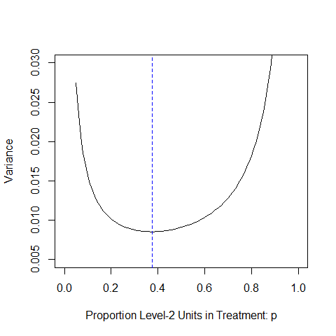

```r
 # constrained optimal design with n = 20
myod2 <- od.2(icc = 0.2, r12 = 0.5, r22 = 0.5, c1 = 1, c2 = 5, c1t = 1,
              c2t = 50, plot.by = list(p = "p"), n = 20,
              varlim = c(0.005, 0.030))
```

```r
 # myod2$out # output
 # myod2$par # parameters used in the calculation.
```

```r
 # constrained optimal design with p = 0.5
myod3 <- od.2(icc = 0.2, r12 = 0.5, r22 = 0.5, c1 = 1, c2 = 5, c1t = 1, c2t = 50,
             p = 0.5, varlim = c(0.005, 0.020))
```

```
## The optimal level-1 sample size per level-2 unit (n) is 10.48809.
## The constrained proportion of level-2 units in treatment (p) is 0.5.
```

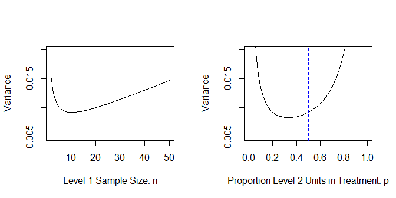

```r
 # myod3$out # output;
 # myod3$par # parameters used in the calculation.
```

```r
 # constrained n and p, no calculation performed
myod4 <- od.2(icc = 0.2, r12 = 0.5, r22 = 0.5, c1 = 1, c2 = 5, c1t = 1, c2t = 50,
              plots = FALSE, n = 20, p = 0.5, varlim = c(0.005, 0.025))
```

```
## ===============================
## Both p and n are constrained, there is no calculation from other parameters.
## ===============================
## The constrained level-1 sample size per level-2 unit (n) is 20.
## The constrained proportion of level-2 units in treatment (p) is 0.5.
```

Please see additional examples in corresponding functions by uncommenting below lines.

```r
# ?od.1
# ?od.3
# ?od.4
# ?od.2m
# ?od.3m
# ?od.4m
```

## Function *plot.power*

This function plots the statistical power curves for the identified optimal sample allocation. It takes the output from an *od* function as the key inputs. Other arguments include

- q: the number of covariates at the proper level, which depends on the type of the design
- d: standardized main treatment effect
- power: the power level for the main effect
- other parameters that vary across designs

The function will first calculate the required budget to achieve the target power level (80%) if the budget is not explicitly specified. Then, it calculate the power under different allocations under the same budget and plot the power curve(s) against the sample allocations.

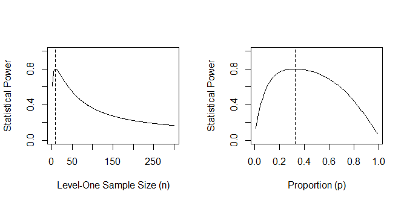

```r
myplot <- plot.power(expr = myod1, q = 1, d = .1)
```

```r
myplot
```

```
## $mfrow
## [1] 1 1
```

## Function *power*

This function by default can perform power analyses accommodating cost structures (i.e., cost.model = TRUE), one of ‘power’, ‘m’, and ‘d’ must be NULL. For example, if ‘power’ is NULL, the function calculates statistical power under a fixed budget and cost structure; if ‘d’ is NULL, the function calculates minimum detectable effect size (i.e., d) under a fixed budget and desired power level; if ‘m’ is NULL, the function calculate required budget (and required sample size) to achieve desired power level to detect a treatment effect.

This function also can conduct conventional power analysis or power analysis without accommodating cost structures by specifying cost.model = FALSE, the conventional power analyses include statistical power calculation, minimum detectable effect size calculation, and required sample size calculation.

### Examples of power analyses accommodating cost structures (cost.model = TRUE)

###### Required budget for desired power

- Required budget calculation

```r
mym <- power.2(expr = myod1, d = 0.3, q = 1, power = 0.8)
# mym$out  # m =1702, J = 59
```

- Effects on required budget to maintain same level power when designs depart from the optimal one

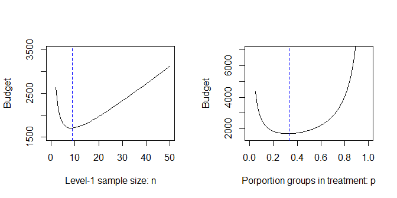

```r
figure <- par(mfrow = c(1, 2))
budget <- NULL
nrange <- c(2:50)
for (n in nrange)
  budget <- c(budget, power.2(expr = myod1, constraint = list (n = n), d = 0.3, q = 1, power = 0.8)$out$m)
plot(nrange, budget, type = "l", lty = 1, xlim = c(0, 50), ylim = c(1500, 3500),
     xlab = "Level-1 sample size: n", ylab = "Budget", main = "", col = "black")
 abline(v = 9, lty = 2, col = "Blue")

budget <- NULL
prange <- seq(0.05, 0.95, by = 0.005)
for (p in prange)
  budget <- c(budget, power.2(expr = myod1, constraint = list (p = p), d = 0.3, q = 1, power = 0.8)$out$m)
plot(prange, budget, type = "l", lty = 1, xlim = c(0, 1), ylim = c(1500, 7000),
     xlab = "Porportion groups in treatment: p", ylab = "Budget", main = "", col = "black")
 abline(v = 0.33, lty = 2, col = "Blue")
```

```r
par(figure)
```

###### Statistical power under a fixed budget

- Power calculation

```r
mypower <- power.2(expr = myod1, q = 1, d = 0.3, m = 1702)
# mypower$out  # power = 0.80
```

- Effects on power under same budget when designs depart from the optimal one

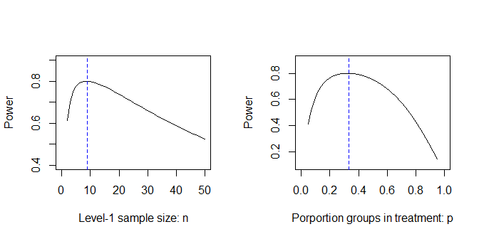

```r
figure <- par(mfrow = c (1, 2))
pwr <- NULL
nrange <- c(2:50)
for (n in nrange)
  pwr <- c(pwr, power.2(expr = myod1, constraint = list (n = n), d = 0.3, q = 1, m = 1702)$out)
plot(nrange, pwr, type = "l", lty = 1, xlim = c(0, 50), ylim = c(0.4, 0.9),
     xlab = "Level-1 sample size: n", ylab = "Power", main = "", col = "black")
 abline(v = 9, lty = 2, col = "Blue")

pwr <- NULL
prange <- seq(0.05, 0.95, by = 0.005)
for (p in prange)
  pwr <- c(pwr, power.2(expr = myod1, constraint = list (p = p), d = 0.3, q = 1, m = 1702)$out)
plot(prange, pwr, type = "l", lty = 1, xlim = c(0, 1), ylim = c(0.1, 0.9),
     xlab = "Porportion groups in treatment: p", ylab = "Power",  main = "", col = "black")
 abline(v = 0.33, lty = 2, col = "Blue")
```

```r
 par(figure)
```

###### Minimum detectable effect size under a fixed budget

- minimum detectable effect size calculation

```r
mymdes <- power.2(expr = myod1, q = 1, power = 0.80, m = 1702)
# above experssion takes parameters and outputs from od.2 function. Equivalently, each parameter can be explicitly specified.
# mym <- power.2(icc = 0.2, r12 = 0.5, r22 = 0.5, c1 = 1, c2 = 5, c1t = 1, c2t = 50,
#                     n = 9, p = 0.33, d = 0.3, q = 1, power = 0.8)
# mymdes$out  # d = 0.30
```

- Effects on minimum detectable effect size under same budget when designs depart from the optimal one

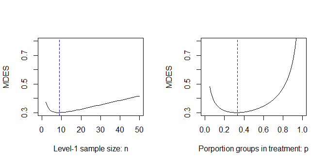

```r
figure <- par(mfrow = c (1, 2))
MDES <- NULL
nrange <- c(2:50)
for (n in nrange)
  MDES <- c(MDES, power.2(expr = myod1, constraint = list (n = n), power = 0.8, q = 1, m = 1702)$out)
plot(nrange, MDES, type = "l", lty = 1, xlim = c(0, 50), ylim = c(0.3, 0.8),
     xlab = "Level-1 sample size: n", ylab = "MDES", main = "", col = "black")
 abline(v = 9, lty = 2, col = "Blue")

MDES <- NULL
prange <- seq(0.05, 0.95, by = 0.005)
for (p in prange)
  MDES <- c(MDES, power.2(expr = myod1, constraint = list (p = p), power = 0.8, q = 1, m = 1702)$out)
plot(prange, MDES, type = "l", lty = 1, xlim = c(0, 1), ylim = c(0.3, 0.8),
     xlab = "Porportion groups in treatment: p", ylab = "MDES", main = "", col = "black")
 abline(v = 0.33, lty = 2, col = "Blue")
```

```r
 par(figure)
```

### Examples of conventional power analyses (cost.model = FALSE)

```r
# Required level-2 sample size calculation
myJ <- power.2(cost.model = FALSE, expr = myod1, d = 0.3, q = 1, power = 0.8)
# above experssion takes parameters and outputs from od.2 function. Equivalently, each parameter can be explicitly specified.
# myJ <- power.2(icc = 0.2, r12 = 0.5, r22 = 0.5,
#                     cost.model = FALSE, n = 9, p = 0.33, d = 0.3, q = 1, power = 0.8)
myJ$out  # J = 59
```

```
## $J
## [1] 58.99295
```

```r
# Power calculation
mypower1 <- power.2(cost.model = FALSE, expr = myod1, J = 59, d = 0.3, q = 1)
mypower1$out  # power = 0.80
```

```
## $power
## [1] 0.8000486
```

```r
# Minimum detectable effect size calculation
mymdes1 <- power.2(cost.model = FALSE, expr = myod1, J = 59, power = 0.8, q = 1)
mymdes1$out  # d = 0.30
```

```
## $d
## [1] 0.2999819
```

### Examples of conventional power curves

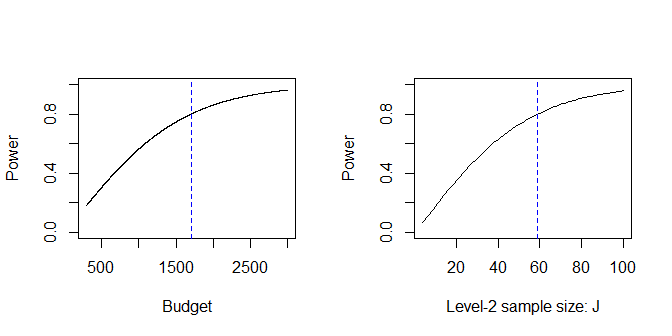

```r
figure <- par(mfrow = c (1, 2))
pwr <- NULL
mrange <- c(300:3000)
for (m in mrange)
  pwr <- c(pwr, power.2(expr = myod1, d = 0.3, q = 1, m = m)$out)
plot(mrange, pwr, type = "l", lty = 1, xlim = c(300, 3000), ylim = c(0, 1),
     xlab = "Budget", ylab = "Power", main = "", col = "black")
 abline(v = 1702, lty = 2, col = "Blue")

pwr <- NULL
Jrange <- c(4:100)
for (J in Jrange)
  pwr <- c(pwr, power.2(expr = myod1, cost.model = FALSE, d = 0.3, q = 1, J = J)$out)
plot(Jrange, pwr, type = "l", lty = 1, xlim = c(4, 100), ylim = c(0, 1),
     xlab = "Level-2 sample size: J", ylab = "Power", main = "", col = "black")
 abline(v = 59, lty = 2, col = "Blue")
```

```r
par(figure)
```

### Examples for other types of trials

Please see examples in corresponding functions by uncommenting below lines.

```r
# ?power.1
# ?power.3
# ?power.4
# ?power.2m
# ?power.3m
# ?power.4m
```

## Function *re*

Calculate the relative efficiency (RE) of two designs, this function uses the returns from *od* function

Based on above examples in *od* functions, calculate the relative efficiency

```r
# relative efficiency (RE) of a constrained design comparing with the optimal design
myre <- re(od = myod1, subod= myod2)
```

```
## The relative efficiency (RE) of the two two-level CRTs is 0.8790305.
```

```r
myre$re # get the output (i.e., RE = 0.88)
```

```
## [1] 0.8790305
```

```r
# relative efficiency (RE) of a constrained design comparing with the unconstrained optimal one
myre <- re(od = myod1, subod= myod3)
```

```
## The relative efficiency (RE) of the two two-level CRTs is 0.8975086.
```

```r
# relative efficiency (RE) of a constrained design comparing with the unconstrained optimal one
myre <- re(od = myod1, subod= myod4)
```

```
## The relative efficiency (RE) of the two two-level CRTs is 0.8266527.
```

For additional examples, please see example sections in corresponding *od* functions by uncommenting below lines.

```r
# ?od.1
# ?od.2
# ?od.3
# ?od.4
# ?od.2m
# ?od.3m
# ?od.4m
```

# 6. Examples for Mediation Effects

Below is a simple example to identify an optimal sample allocation and perform statistical power analyses for a mediation effect.

```r
# Optimal sample allocation and statistical power for randomized controlled trials
myod <- od.1.111(a = .3, b = .5, c1 = 10, c1t = 100, verbose = FALSE)
mypower <- power.1.111(expr = myod, power = .8)
# mypower

# Conventional power analyses
mypower <- power.1.111(cost.model = FALSE, a = .3, b = .5, test = "joint",
                        power = .8, p =.5)
# mypower
```

# 7. Examples for Moderation Effects

To be done!